# Your Digest for Tuesday, May 07, 2024 11:59 PM

Causes of methhaemoglobinaemia:

- Propanil, nitrites, dapsone
- Treatment: Methylene blue  
  Snake envenomation:
- WBCT can be negative in early DIC -> Must be repeated.

Refeeding occurs due to **fluid** and **electrolyte** shifts occurring during refeeding.  
Features of refeeding syndrome:

- **Hypophosphatemia** <- the **hallmark** of refeeding syndrome; occurs due to the action of insulin when nutrition is reintroduced.
- Hypokalemia
- Congestive **heart failure**
- Peripheral edema
- Rhabdomyolysis
- Seizures
- Hemolysis
- Respiratory insufficiency

> [!INFO] Diagnostic criteria in HHS which exclude a diagnosis of DKA  
> **Features of HHS**

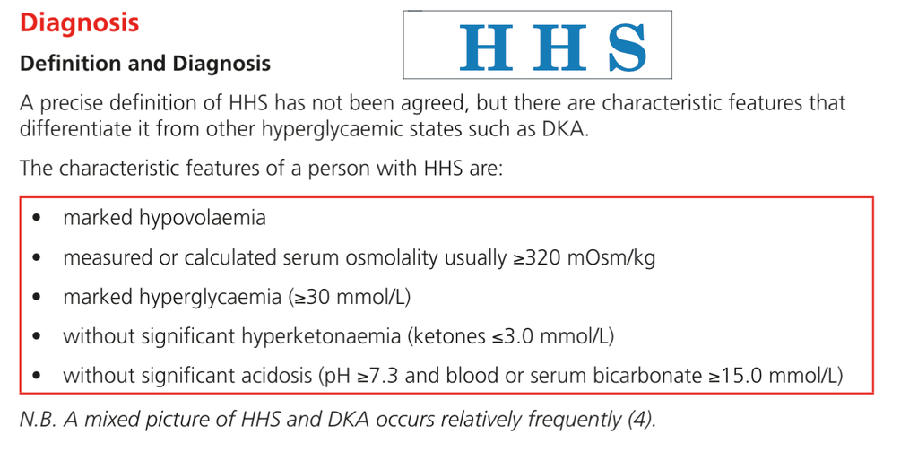

# To Do

- Slides by Gajanthan
- Download the MRCP books
- Google drive osce slides

# Roster Reschedules

- D - 24th evening
- A - will do 25th night; I have 26th morning.
- H - need to exchange 28th night.

# Study plan

- Quickly go through the OSCEs to see what they ask
- Study high yield and easy to memorize topics
  - ECGs: Algorithm + familiarity
    - Look for uncommon ECG patterns
  - Chest X rays:
  - ABGs
  - Snake images
- Short cases:
  - CVS x 10
  - RS x 10
  - Neuro x 10
  - GIT x 5

[output not shown]

[output not shown]